# presentation

```python
import pandas as pd
import pyfolio as pf
import warnings
warnings.filterwarnings(action='ignore')
import site
site.addsitedir('../CLSA_test/DataPool')
site.addsitedir('../CLSA_test/FeaturePool')
site.addsitedir('../CLSA_test/ModelPool')
```

## Presentation Steps

- [DATA_POOL]download and save klines of s&p 100 components
- [FEATURE_POOL]generate features using data in data_pool(here just klines)
- [MODEL_POOL]form a simple momentum model using features in feature_pool
- [BACKTEST&ANALYSIS]using pyfolio to get a quick look for now

#### DATA_POOL

- download adjusted kline data from yfinance from 20200101 to 20210701
- 1 symbol (RTN) has no data because of delisted, for simplicity , I will use rest of 99 stocks to proceed

```python
from DataPool.data_fetcher import *
```

```python
sinfos=get_index_comp_latest('S&P 100')
slist=[i['symbol'] for i in sinfos]
data=get_stock_kline(slist,20200101,20210701)
# data.to_pickle('sp100_klines_adjusted.pkl')
data.head(10)
```

```
[*********************100%***********************]  99 of 99 completed

1 Failed download:
- RTN: No data found, symbol may be delisted
```

| Date | Adj Close RTN | Close AAPL | Close ABBV | Close ABT | Close ACN | Close ADBE | Close AIG | Close AMGN | Close AMT | Close AMZN | ... | Volume UNH | Volume UNP | Volume UPS | Volume USB | Volume V | Volume VZ | Volume WBA | Volume WFC | Volume WMT | Volume XOM |
| --- | --- | --- | --- | --- | --- | --- | --- | --- | --- | --- | --- | --- | --- | --- | --- | --- | --- | --- | --- | --- | --- |
| 2020-01-02 | NaN | 74.207466 | 82.864151 | 84.945091 | 205.489380 | 334.429993 | 49.003220 | 230.298279 | 222.032486 | 1898.010010 | ... | 2543400 | 2444800 | 4158100 | 5002100 | 8733000 | 11447900 | 5700500 | 16803100 | 6764900 | 12456400 |
| 2020-01-03 | NaN | 73.486023 | 82.077606 | 83.909538 | 205.147125 | 331.809998 | 48.624527 | 228.734818 | 222.139359 | 1874.969971 | ... | 2711400 | 2344200 | 2477800 | 5161800 | 4899700 | 13263200 | 4892300 | 15608800 | 5399200 | 17386900 |
| 2020-01-06 | NaN | 74.071579 | 82.725349 | 84.349159 | 203.807526 | 333.709991 | 48.662395 | 230.490112 | 222.081070 | 1902.880005 | ... | 3079100 | 3142500 | 3381600 | 6869200 | 10109500 | 15094500 | 6003300 | 13200300 | 6445500 | 20081900 |
| 2020-01-07 | NaN | 73.723213 | 82.253426 | 83.880226 | 199.407318 | 333.390015 | 48.387844 | 228.322357 | 217.348892 | 1906.859985 | ... | 2492900 | 4096400 | 1952300 | 4006800 | 4392300 | 14293100 | 4365700 | 13278600 | 6846900 | 17387700 |
| 2020-01-08 | NaN | 74.909149 | 82.836395 | 84.222160 | 199.798477 | 337.869995 | 48.955887 | 228.495026 | 219.233994 | 1891.969971 | ... | 3379200 | 2817500 | 2016000 | 5627500 | 5712000 | 15926500 | 17431800 | 16585600 | 5875800 | 15137700 |
| 2020-01-09 | NaN | 76.500275 | 83.474876 | 84.446861 | 201.578094 | 340.450012 | 49.495522 | 229.176041 | 220.059937 | 1901.050049 | ... | 2838200 | 3311100 | 2151500 | 5775400 | 6748000 | 20134600 | 8469600 | 20817400 | 5563700 | 14811800 |
| 2020-01-10 | NaN | 76.673225 | 82.410728 | 83.391754 | 203.054596 | 339.809998 | 49.258839 | 228.533386 | 224.267380 | 1883.160034 | ... | 2477900 | 2944300 | 2545000 | 5285000 | 6586400 | 11786700 | 6688000 | 13777600 | 6054800 | 11995600 |
| 2020-01-13 | NaN | 78.311295 | 81.911049 | 83.157295 | 204.941803 | 345.630005 | 49.817417 | 227.248093 | 228.746902 | 1891.300049 | ... | 6994900 | 2035200 | 1826200 | 6235800 | 11290500 | 14158400 | 5517800 | 25197600 | 6112600 | 9953900 |
| 2020-01-14 | NaN | 77.253838 | 82.717590 | 84.118752 | 203.123062 | 344.630005 | 49.552330 | 230.202362 | 227.328201 | 1869.439941 | ... | 6056300 | 2805900 | 2598600 | 6866500 | 6236500 | 12697100 | 4466800 | 56668300 | 6585800 | 16261000 |
| 2020-01-15 | NaN | 76.922775 | 83.711716 | 85.727745 | 203.446976 | 342.940002 | 49.022152 | 231.832947 | 228.717743 | 1862.020020 | ... | 6081300 | 3450700 | 3168400 | 10158500 | 10831100 | 10291300 | 3495600 | 47148000 | 7454200 | 11390300 |

10 rows × 496 columns

#### FEATURE_POOL

- construct one feature function - daily return, using close price, supporting multiple days return
- generate and save one feature - 'c2cret_5day', close(t)/close(t-5)-1

```python
from FeaturePool.daily_return import *
```

```python
kline=pd.read_pickle('../CLSA_test/DataPool/sp100_klines_adjusted.pkl')
cp=kline.xs('Close',axis=1,level=0)
c2cret_5day=daily_c2c_return(cp,days=5)
# c2cret_5day.to_pickle('c2cret_5day.pkl')
c2cret_5day.tail(10)
```

| Date | AAPL | ABBV | ABT | ACN | ADBE | AIG | AMGN | AMT | AMZN | AVGO | ... | UNH | UNP | UPS | USB | V | VZ | WBA | WFC | WMT | XOM |
| --- | --- | --- | --- | --- | --- | --- | --- | --- | --- | --- | --- | --- | --- | --- | --- | --- | --- | --- | --- | --- | --- |
| 2021-06-17 | 0.045040 | -0.011528 | 0.013436 | 0.001935 | 0.029579 | -0.048442 | -0.015860 | -0.000073 | 0.041673 | 0.005334 | ... | -0.010312 | -0.002368 | -0.025344 | -0.049309 | -0.007694 | -0.014126 | -0.045200 | -0.051009 | -0.015442 | -0.012112 |
| 2021-06-18 | 0.024421 | -0.019927 | 0.003821 | -0.014126 | 0.044951 | -0.093810 | -0.016847 | -0.004236 | 0.041851 | -0.015296 | ... | -0.017829 | -0.029458 | -0.026722 | -0.074400 | -0.019365 | -0.026339 | -0.080817 | -0.086033 | -0.039645 | -0.028470 |
| 2021-06-21 | 0.013949 | -0.005806 | 0.008689 | -0.000525 | 0.018673 | -0.065558 | -0.003939 | -0.007080 | 0.020713 | -0.015937 | ... | 0.000922 | -0.022954 | 0.011090 | -0.037483 | 0.001025 | -0.013816 | -0.045931 | -0.041418 | -0.029596 | 0.008378 |
| 2021-06-22 | 0.033477 | -0.009756 | 0.004981 | -0.001852 | 0.049739 | -0.077237 | 0.000250 | -0.009552 | 0.036153 | -0.005639 | ... | -0.000324 | -0.017277 | 0.015123 | -0.043924 | 0.012662 | -0.016059 | -0.045538 | -0.042235 | -0.021214 | -0.008394 |
| 2021-06-23 | 0.027276 | -0.013243 | 0.007087 | 0.006199 | 0.056871 | -0.076432 | -0.003631 | -0.003921 | 0.025934 | 0.009797 | ... | -0.000607 | -0.013285 | 0.017962 | -0.039357 | 0.022125 | -0.010064 | -0.023073 | -0.035330 | -0.008677 | 0.002496 |
| 2021-06-24 | 0.012292 | -0.001393 | 0.000627 | 0.023844 | 0.048788 | -0.011482 | 0.000789 | -0.019888 | -0.011510 | 0.005453 | ... | 0.007502 | -0.002739 | 0.040646 | 0.020818 | 0.017618 | -0.002830 | -0.013444 | 0.055854 | -0.005881 | 0.040813 |
| 2021-06-25 | 0.020313 | -0.001238 | 0.021662 | 0.047680 | 0.024877 | 0.046318 | 0.016759 | 0.002256 | -0.024503 | 0.005001 | ... | 0.040013 | 0.030073 | 0.039642 | 0.056814 | 0.029990 | 0.010032 | 0.025964 | 0.110898 | 0.024858 | 0.070530 |
| 2021-06-28 | 0.018745 | -0.015079 | 0.038227 | 0.029206 | 0.037807 | 0.004398 | 0.010822 | 0.015127 | -0.002916 | 0.017628 | ... | 0.008516 | 0.007448 | 0.009394 | 0.027867 | -0.000982 | -0.003724 | 0.005392 | 0.057995 | 0.012463 | 0.006710 |
| 2021-06-29 | 0.017540 | -0.020924 | 0.056327 | 0.037702 | 0.026071 | -0.003155 | 0.010629 | 0.023180 | -0.016346 | 0.027344 | ... | -0.001480 | -0.001553 | 0.010760 | 0.020319 | 0.000085 | -0.009402 | 0.004250 | 0.028709 | 0.001970 | -0.018341 |
| 2021-06-30 | 0.024383 | -0.011930 | 0.045922 | 0.031817 | 0.019870 | -0.002724 | 0.021113 | 0.022406 | -0.018169 | 0.021815 | ... | 0.012337 | 0.003742 | 0.019361 | 0.022246 | -0.003665 | -0.000713 | 0.010177 | 0.030255 | 0.037217 | -0.018363 |

10 rows × 99 columns

#### MODEL_POOL

- build a simple momentum model using c2cret_5day: select top_k stocks every morning based on the ranking of signal, and equally weighted

```python
from ModelPool.daily_momentum import *
```

```python
signal=pd.read_pickle('../CLSA_test/FeaturePool/c2cret_5day.pkl')
top_k=10
wgt=momentum_strat(top_k,signal)
wgt.tail(10)
```

| Date | AAPL | ABBV | ABT | ACN | ADBE | AIG | AMGN | AMT | AMZN | AVGO | ... | UNH | UNP | UPS | USB | V | VZ | WBA | WFC | WMT | XOM |
| --- | --- | --- | --- | --- | --- | --- | --- | --- | --- | --- | --- | --- | --- | --- | --- | --- | --- | --- | --- | --- | --- |
| 2021-06-17 | 0.1 | 0.0 | 0.0 | 0.0 | 0.1 | 0.0 | 0.0 | 0.0 | 0.1 | 0.0 | ... | 0.0 | 0.0 | 0.0 | 0.0 | 0.0 | 0.0 | 0.0 | 0.0 | 0.0 | 0.0 |
| 2021-06-18 | 0.1 | 0.0 | 0.0 | 0.0 | 0.1 | 0.0 | 0.0 | 0.0 | 0.1 | 0.0 | ... | 0.0 | 0.0 | 0.0 | 0.0 | 0.0 | 0.0 | 0.0 | 0.0 | 0.0 | 0.0 |
| 2021-06-21 | 0.1 | 0.0 | 0.0 | 0.0 | 0.1 | 0.0 | 0.0 | 0.0 | 0.1 | 0.0 | ... | 0.0 | 0.0 | 0.0 | 0.0 | 0.0 | 0.0 | 0.0 | 0.0 | 0.0 | 0.0 |
| 2021-06-22 | 0.1 | 0.0 | 0.0 | 0.0 | 0.1 | 0.0 | 0.0 | 0.0 | 0.1 | 0.0 | ... | 0.0 | 0.0 | 0.0 | 0.0 | 0.0 | 0.0 | 0.0 | 0.0 | 0.0 | 0.0 |
| 2021-06-23 | 0.0 | 0.0 | 0.0 | 0.0 | 0.1 | 0.0 | 0.0 | 0.0 | 0.0 | 0.0 | ... | 0.0 | 0.0 | 0.0 | 0.0 | 0.0 | 0.0 | 0.0 | 0.0 | 0.0 | 0.0 |
| 2021-06-24 | 0.0 | 0.0 | 0.0 | 0.0 | 0.1 | 0.0 | 0.0 | 0.0 | 0.0 | 0.0 | ... | 0.0 | 0.0 | 0.0 | 0.0 | 0.0 | 0.0 | 0.0 | 0.1 | 0.0 | 0.1 |
| 2021-06-25 | 0.0 | 0.0 | 0.0 | 0.0 | 0.0 | 0.0 | 0.0 | 0.0 | 0.0 | 0.0 | ... | 0.0 | 0.0 | 0.0 | 0.0 | 0.0 | 0.0 | 0.0 | 0.1 | 0.0 | 0.1 |
| 2021-06-28 | 0.0 | 0.0 | 0.0 | 0.0 | 0.0 | 0.0 | 0.0 | 0.0 | 0.0 | 0.0 | ... | 0.0 | 0.0 | 0.0 | 0.0 | 0.0 | 0.0 | 0.0 | 0.1 | 0.0 | 0.0 |
| 2021-06-29 | 0.0 | 0.0 | 0.1 | 0.1 | 0.0 | 0.0 | 0.0 | 0.0 | 0.0 | 0.0 | ... | 0.0 | 0.0 | 0.0 | 0.0 | 0.0 | 0.0 | 0.0 | 0.0 | 0.0 | 0.0 |
| 2021-06-30 | 0.0 | 0.0 | 0.1 | 0.0 | 0.0 | 0.0 | 0.0 | 0.0 | 0.0 | 0.0 | ... | 0.0 | 0.0 | 0.0 | 0.0 | 0.0 | 0.0 | 0.0 | 0.0 | 0.1 | 0.0 |

10 rows × 99 columns

#### Backtest and Analysis using pyfolio

- assume the one-side trading cost is 0.2%, and all the figures are shown based on this assumption.
- use all cmp mean return as benchmark
- if no cost is counted, the annual return would be 0.5%(almost 0)

```python
trade_return=pd.read_pickle('../CLSA_test/FeaturePool/o2oret_1day.pkl').shift(-2) # the hold return if trade at today open and sell at tmr open
strat_daily_return=(trade_return*wgt).sum(axis=1)-wgt.diff().abs().sum(axis=1)*0.002
benchmarkt_daily_return=trade_return.mean(axis=1).to_frame('benchmark').benchmark
```

| Start date End date Total months | 2020-01-02 2021-06-30 17 Backtest | 2020-01-02 2021-06-30 17 |
| --- | --- | --- |
| Annual return | -33.4% |  |
| Cumulative returns | -45.6% |  |
| Annual volatility | 32.2% |  |
| Sharpe ratio | -1.10 |  |
| Calmar ratio | -0.56 |  |
| Stability | 0.66 |  |
| Max drawdown | -59.5% |  |
| Omega ratio | 0.81 |  |
| Sortino ratio | -1.36 |  |
| Skew | -1.18 |  |
| Kurtosis | 6.68 |  |
| Tail ratio | 0.81 |  |
| Daily value at risk | -4.2% |  |
| Gross leverage | 1.00 |  |
| Alpha | -0.46 |  |
| Beta | 0.91 |  |

| Worst drawdown periods | Net drawdown in % | Peak date | Valley date | Recovery date | Duration |
| --- | --- | --- | --- | --- | --- |
| 0 | 59.51 | 2020-02-14 | 2020-11-10 | NaT | NaN |
| 1 | 2.89 | 2020-01-10 | 2020-01-23 | 2020-01-31 | 16 |
| 2 | 1.14 | 2020-02-03 | 2020-02-04 | 2020-02-07 | 5 |
| 3 | 0.54 | 2020-02-07 | 2020-02-11 | 2020-02-12 | 4 |
| 4 | 0.04 | 2020-01-08 | 2020-01-09 | 2020-01-10 | 3 |

| Stress Events | mean | min | max |
| --- | --- | --- | --- |
| New Normal | -0.14% | -13.66% | 7.03% |

| Top 10 long positions of all time | max |
| --- | --- |
| AMT | 10.00% |
| BKNG | 10.00% |
| DUK | 10.00% |
| EXC | 10.00% |
| NFLX | 10.00% |
| NVDA | 10.00% |
| TMUS | 10.00% |
| TSLA | 10.00% |
| UNH | 10.00% |
| WMT | 10.00% |

| Top 10 short positions of all time | max |
| --- | --- |

| Top 10 positions of all time | max |
| --- | --- |
| AMT | 10.00% |
| BKNG | 10.00% |
| DUK | 10.00% |
| EXC | 10.00% |
| NFLX | 10.00% |
| NVDA | 10.00% |
| TMUS | 10.00% |
| TSLA | 10.00% |
| UNH | 10.00% |
| WMT | 10.00% |

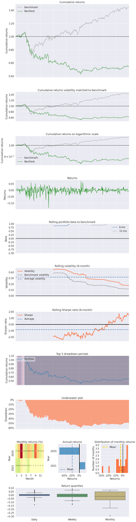

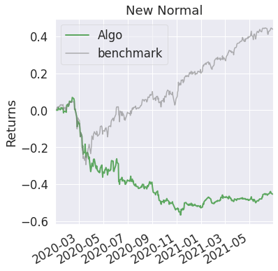

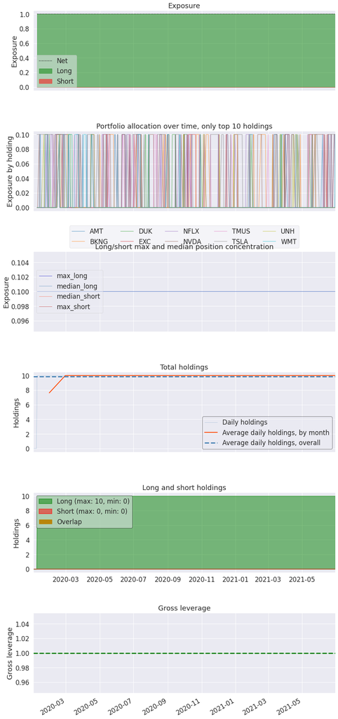

```python
pf.create_full_tear_sheet(returns=strat_daily_return,positions=wgt.assign(cash=0),benchmark_rets=benchmarkt_daily_return)
```